# ASE startup

Anna L Tyler

April 03, 2026

## Introduction

The purpose of this workflow is to start looking at some CC-RIX mice to assess ASE in adults in a similar way to pmid:28238550, in which they used correlation of allele-specific expression across F1 mice to identify genes with biased allele expression in bulk-RNASeq from adult tissues.

```r
rm(list = ls())
library(here)
```

```r
all.fun <- list.files(here("Code"), full.names = TRUE)
for(i in 1:length(all.fun)){source(all.fun[i])}
```

```r
needed.libraries <- c("pheatmap", "DT")
load_libraries(needed.libraries)
```

I am using the GBRS output that Matt Vincent just made for an old CGD data set looking at heart and kidneys in CC-RIX mice. They will not be heterozygous everywhere, and in fact, some of these mice seem to be F1s of the same strain, but do have some heterozygosity left. Not sure what that’s about. Maybe these are still early CC-RIX?

If GBRS is supposed to genotype from RNASeq, how do they deal with potential mono-allelic expression? I guess, for the most part, this will be extremely rare, and not be consistent across cells, so there should always be some of both alleles expressed.

I will start with the kidney data because there are more samples.

```r
sample.dir <- "CGD_CCRIX_Kidney_RNASeq"
file.pattern <- "diploid.genes.expected_read_counts" #calls are identical across animals
#file.pattern <- "diploid.genes.tpm"


sample.sheet <- read.csv(here("Data", sample.dir, "CGD_CCRIX_Kidney_RNASeq.SampleSheet.csv"))
split.strains <- strsplit(gsub(".fastq.gz", "", basename(sample.sheet[,"fastq_1"])), "_")
strains <- sapply(split.strains, function(x) x[1])
u_strain <- unique(strains)

data.files <- sapply(sample.sheet[,1],
  function(x) list.files(here("Data", sample.dir, "gbrs_analysis", "output", x, "gbrs"),
  pattern = file.pattern, full.names = TRUE))

ase <- lapply(data.files, function(x) as.matrix(read.delim(x)))
```

There are 4 unique crosses in this data set:

```r
print(u_strain)
```

```
## [1] "3252x3252" "3252x8002" "8002x3252" "8002x8002"
```

```r
number_calls <- function(call.list){
  geno.cols <- sapply(call.list, function(x) x[,"notes"])
  #flag any positions that have different calls across animals
  u_calls <- apply(geno.cols, 1, unique)
  num.calls <- sapply(u_calls, length)
  prop.table <- (table(num.calls)/nrow(geno.cols))*100

  unique.hap <- apply(geno.cols, 1, function(x) unique(unlist(strsplit(x, ""))))
  num.hap <- sapply(unique.hap, length)

  #par(mfrow = c(1,2))
  barplot_with_num(signif(prop.table, 2), ylab = "Percent",
    xlab = "Number of different genotypes")

  hist(num.hap, xlab = "Haplotypes", main = "")
}

find_hets <- function(call.list, min.count = 10){


  geno.cols <- sapply(call.list, function(x) x[,"notes"])

  #filter to sites for which all animals have the same call
  #we'll call these high-confidence sites, although, we should
  #investigate why some sites have different calls.
  same.call <- apply(geno.cols, 1, function(x) all(x == x[1]))
  all.same <- length(which(same.call))/nrow(geno.cols)

  sub.geno <- geno.cols[which(same.call),]
  sub.counts <- lapply(call.list, function(x) apply(x[which(same.call), LETTERS[1:8]], 2, as.numeric))
  #name rows with gene names
  for(i in 1:length(sub.counts)){
    rownames(sub.counts[[i]]) <- call.list[[i]][which(same.call),1]
  }

  #filter out genes for which there was no call for any
  has.call <- which(sub.geno[,1] != "None")
  filtered.geno <- sub.geno[has.call,]
  filtered.counts <- lapply(sub.counts, function(x) x[has.call,])

  #find heterozygous sites
  unique.hap <- apply(filtered.geno, 1, function(x) unique(unlist(strsplit(x, ""))))
  num.hap <- sapply(unique.hap, length)
  #hist(num.hap)
  het.idx <- which(num.hap == 2)
  #length(het.idx)

  het.counts <- lapply(filtered.counts, function(x) x[het.idx,])

  #convert to a list of matrices with counts for all alleles
  allele.counts <- lapply(1:nrow(het.counts[[1]]), function(x) sapply(het.counts, function(y) t(y[x,])))
  names(allele.counts) <- rownames(het.counts[[1]])
  #rownames disappeared, add them back
  for(i in 1:length(allele.counts)){
    rownames(allele.counts[[i]]) <- LETTERS[1:8]
  }

  #remove genes with counts that are too los
  count.sum <- sapply(allele.counts, function(x) log(sum(x)+1))
  #hist(count.sum)
  keep.genes <- which(count.sum > min.count)

  has.counts <- allele.counts[keep.genes]

  final.counts <- lapply(has.counts, function(x) x[which(rowSums(x) > 0),])
  #WTF, these are all identical. There's no variation at all! I don't think
  #expected counts is what I want...
  return(final.counts)
}
```

I first just looked at how many different genotype calls there were across supposedly isogenic animals. There are an alarmingly high number of different calls. For three of the crosses there are more sites with two different calls than with only one. Why is this?

```r
for(i in 1:length(u_strain)){
  par(mfrow = c(1,2))
  cross.idx <- which(strains == u_strain[i])
  number_calls(call.list = ase[cross.idx])
  mtext(u_strain[i], side = 3, line = -1.5, outer = TRUE)
}
```

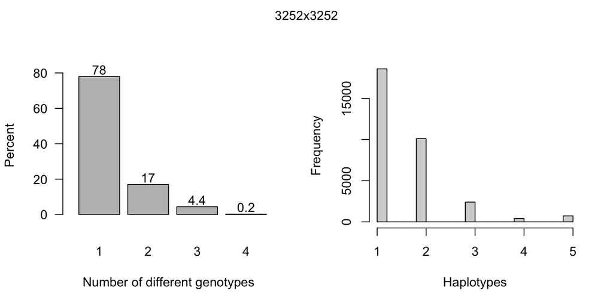

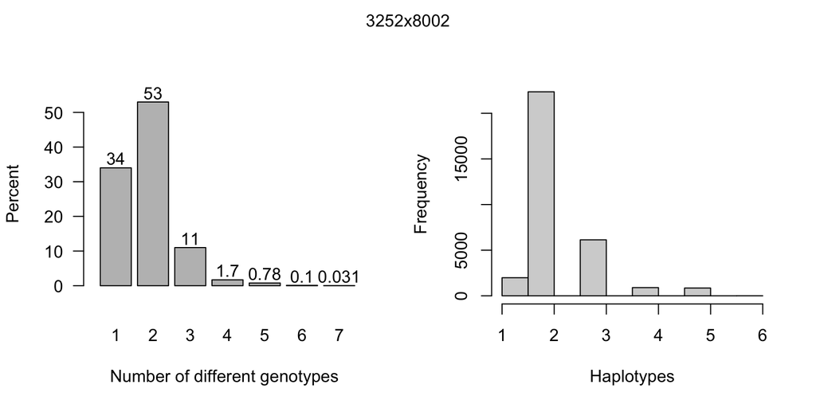

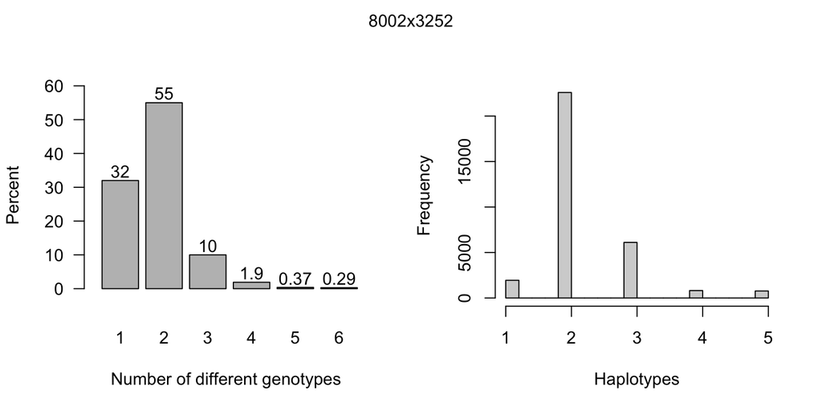

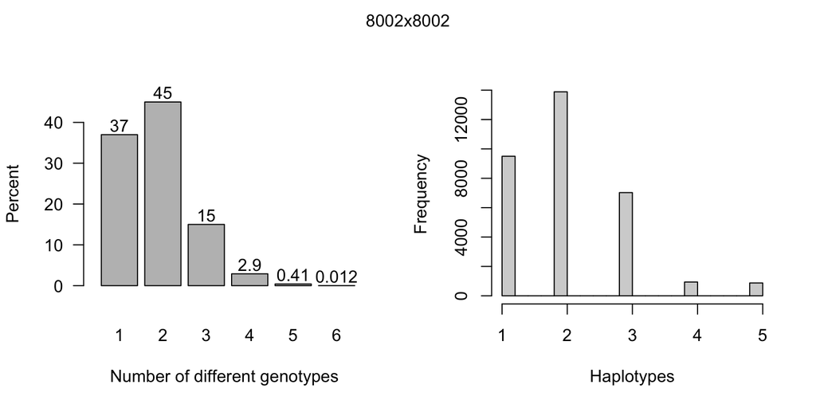

For now, I guess I’ll restrict my analysis to only sites for which all animals have the same call.

```r
cross_hets <- vector(mode = "list", length = length(u_strain))
names(cross_hets) <- u_strain
for(i in 1:length(u_strain)){
  cross.idx <- which(strains == u_strain[i])
  cross_hets[[i]] <- find_hets(call.list = ase[cross.idx])
}
```